# Association between sleep quality and pain in older adults

Pedro Henrique Brant

2023-11-03

## Introduction

In this manuscript, we’re going to conduct an analysis into the ELSI Dataset. This is a modified version for usage in the Principles and Practice of Clinical Research program of Harvard T.H. Chan School of Public Health.

The aim here is to replicate the analysis done in a [previous paper](https://pubmed.ncbi.nlm.nih.gov/34968438/) and see if the results also apply to the sample that was included in the [ELSI Brazil](https://elsi.cpqrr.fiocruz.br/en/home-english/).

First order of business is to download the dataset we’re going to be analyzing, which was kindly provided by PPCR staff.

```r
## Loading the necessary libraries
library(tidyverse)
library(haven)
library(broom)
library(ggplot2)
library(lmtest)
```

```r
## Url provided by PPCR staff
url <- 'https://contattafiles.s3.us-west-1.amazonaws.com/tnt45405/T9gKrWnaRr5K0yT/FINAL%20-%20ELSI_students.dta'

## Using the read_dta function from haven to read the .dta file created in STATA
PPCRdata <- read_dta(url)

## Removing the url from memory as it is no longer useful
rm(url)

## Transforming to tibble in order to increase readability
PPCRdata <- as_tibble(PPCRdata)
PPCRdata
```

```
## # A tibble: 6,974 × 121
##         id2   psu calibr…¹ stratum region  area    homet…² stair…³ sex     age
##       <dbl> <dbl>    <dbl>   <dbl> <dbl+l> <dbl+l> <dbl+l> <dbl+l> <dbl+l> <dbl>
##  1 20200001    21    3111.      30 1 [Nor… 1 [Urb… 1 [Hou… 0 [No]  0 [Fem… 60
##  2 20200002    21    1555.      30 1 [Nor… 1 [Urb… 1 [Hou… 0 [No]  0 [Fem… 62
##  3 20200003    21    1147.      30 1 [Nor… 1 [Urb… 1 [Hou… 0 [No]  0 [Fem… 78
##  4 20200004    21    1523.      30 1 [Nor… 1 [Urb… 1 [Hou… 0 [No]  1 [Mal… 78
##  5 20200007    21    2563.      30 1 [Nor… 1 [Urb… 1 [Hou… 0 [No]  0 [Fem… 53
##  6 20200009    21    5127.      30 1 [Nor… 1 [Urb… 1 [Hou… 0 [No]  0 [Fem… 59
##  7 20200012    21     918.      30 1 [Nor… 1 [Urb… 1 [Hou… 1 [Yes] 1 [Mal… 80
##  8 20200013    21     757.      30 1 [Nor… 1 [Urb… 1 [Hou… 1 [Yes] 0 [Fem… 72
##  9 20200014    21    1027.      30 1 [Nor… 1 [Urb… 1 [Hou… 0 [No]  0 [Fem… 64
## 10 20200015    21    1005.      30 1 [Nor… 1 [Urb… 1 [Hou… 0 [No]  1 [Mal… 79
## # … with 6,964 more rows, 111 more variables: marital <dbl+lbl>,
## #   race <dbl+lbl>, children <dbl+lbl>, grandchildren <dbl+lbl>,
## #   siblings <dbl+lbl>, education <dbl+lbl>, dis_med <dbl+lbl>,
## #   dis_social <dbl+lbl>, dis_work <dbl+lbl>, dis_family <dbl+lbl>,
## #   dis_place <dbl+lbl>, work_12 <dbl+lbl>, workability <dbl+lbl>,
## #   retired <dbl+lbl>, reasonretire <dbl+lbl>, incomescore <dbl+lbl>,
## #   vigorousintensity <dbl+lbl>, moderateintensity <dbl+lbl>, …
```

PPCR Staff has described the variables included in this dataset with the following:

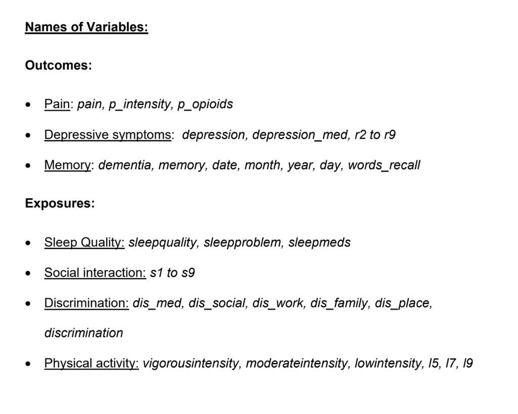

## Adjusting Variables for the Analysis

Let’s now look at the some of the individual variables to understand what they mean

```r
unique(PPCRdata$pain)
```

```
## <labelled<double>[2]>: Do you feel pain that bothers you frequently?
## [1] 1 0
##
## Labels:
##  value                     label
##      0                        No
##      1                       Yes
##      8            Does not apply
##      9 Didn’t know/didn’t answer
```

```r
unique(PPCRdata$p_intensity)
```

```
## <labelled<double>[4]>: How intense is this pain most of the time?
## [1]  2 NA  3  1
##
## Labels:
##  value                     label
##      1                 Soft/weak
##      2                  Moderate
##      3            Intense/strong
##      8            Does not apply
##      9 Didn’t know/didn’t answer
```

```r
unique(PPCRdata$sleepquality)
```

```
## <labelled<double>[6]>: How would you evaluate the quality of your sleep?
## [1]  4  2  3  1  5 NA
##
## Labels:
##  value                     label
##      1                 Very good
##      2                      Good
##      3                      Fair
##      4                       Bad
##      5                  Very bad
##      9 Didn’t know/didn’t answer
```

```r
unique(PPCRdata$sleepproblems)
```

```
## <labelled<double>[3]>: Has a doctor ever told you that you have sleep problems?
## [1]  0  1 NA
##
## Labels:
##  value                     label
##      0                        No
##      1                       Yes
##      8            Does not apply
##      9 Didn’t know/didn’t answer
```

We can then see that *pain* and *sleepproblems* are binary variables, while *p_intensity* and *sleepquality* are ordinal variables, although they aren’t coded in this manner yet.

Now let’s transform *p_intensity* and *sleepquality* into ordinal variables and *pain* and *sleepproblems* into binary variables, as they were read as numerical variables with labels.

```r
## Using the as_factor function from haven to transform the variables
## with the labels as names for the levels in the factors
PPCRdata$sleepquality <- as_factor(PPCRdata$sleepquality, ordered = TRUE)
PPCRdata$p_intensity <- as_factor(PPCRdata$p_intensity, ordered = TRUE)
PPCRdata$pain <- as_factor(PPCRdata$pain)
PPCRdata$sleepproblems <- as_factor(PPCRdata$sleepproblems)


levels(PPCRdata$sleepquality)
```

```
## [1] "Very good"                 "Good"
## [3] "Fair"                      "Bad"
## [5] "Very bad"                  "Didn’t know/didn’t answer"
```

```r
levels(PPCRdata$p_intensity)
```

```
## [1] "Soft/weak"                 "Moderate"
## [3] "Intense/strong"            "Does not apply"
## [5] "Didn’t know/didn’t answer"
```

```r
levels(PPCRdata$pain)
```

```
## [1] "No"                        "Yes"
## [3] "Does not apply"            "Didn’t know/didn’t answer"
```

```r
levels(PPCRdata$sleepproblems)
```

```
## [1] "No"                        "Yes"
## [3] "Does not apply"            "Didn’t know/didn’t answer"
```

```r
## Reversing the order of factors, as initially the order was wrong in sleepquality
PPCRdata$sleepquality <- fct_rev(PPCRdata$sleepquality)
levels(PPCRdata$sleepquality)
```

```
## [1] "Didn’t know/didn’t answer" "Very bad"
## [3] "Bad"                       "Fair"
## [5] "Good"                      "Very good"
```

Other variables that we’re going to use in our model that haven’t been coded properly as well include: *depression*, *sex*, *alcohol*, *fracture*, *cancer*, *diabetes*, *dementia*, *arthritis*, *heartdisease* and *lungdisease*.

```r
## Showing that the variables are coded as numerical variables
unique(PPCRdata$depression)
```

```
## <labelled<double>[3]>: Has a doctor ever told you that you have depression?
## [1]  1  0 NA
##
## Labels:
##  value                     label
##      0                        No
##      1                       Yes
##      9 Didn’t know/didn’t answer
```

```r
unique(PPCRdata$sex)
```

```
## <labelled<double>[2]>: Sex
## [1] 0 1
##
## Labels:
##  value  label
##      0 Female
##      1   Male
```

```r
unique(PPCRdata$alcohol)
```

```
## <labelled<double>[4]>: How often do you usually drink any alcoholic beverage?
## [1]  1  2  3 NA
##
## Labels:
##  value                     label
##      1                     Never
##      2    Less than once a month
##      3      Once a month or more
##      9 Didn’t know/didn’t answer
```

```r
unique(PPCRdata$fracture)
```

```
## <labelled<double>[2]>: Fracture of hip/wrist 12 month
## [1] 0 1
##
## Labels:
##  value label
##      0    No
##      1   Yes
```

```r
unique(PPCRdata$cancer)
```

```
## <labelled<double>[3]>: Has a doctor ever told you that you have or had cancer?
## [1]  0  1 NA
##
## Labels:
##  value                     label
##      0                        No
##      1                       Yes
##      9 Didn’t know/didn’t answer
```

```r
unique(PPCRdata$diabetes)
```

```
## <labelled<double>[3]>: Has any doctor ever told you that you have diabetes (“high blood sugar”)?
## [1]  1  0 NA
##
## Labels:
##  value                      label
##      0                         No
##      1                        Yes
##      2 Yes, only during pregnancy
##      9  Didn’t know/didn’t answer
```

```r
unique(PPCRdata$dementia)
```

```
## <labelled<double>[3]>: Has a doctor ever told you that you have a serious memory problem or dementia? (
## [1]  0  1 NA
##
## Labels:
##  value                     label
##      0                        No
##      1                       Yes
##      8            Does not apply
##      9 Didn’t know/didn’t answer
```

```r
unique(PPCRdata$arthritis)
```

```
## <labelled<double>[3]>: Has a doctor ever told you that you have arthritis or rheumatism?
## [1]  0  1 NA
##
## Labels:
##  value                     label
##      0                        No
##      1                       Yes
##      9 Didn’t know/didn’t answer
```

```r
unique(PPCRdata$heartdisease)
```

```
## <labelled<double>[3]>: History of heartattack, angina or failure
## [1]  0  1 NA
##
## Labels:
##  value label
##      0    No
##      1   Yes
```

```r
unique(PPCRdata$lungdisease)
```

```
## <labelled<double>[3]>: History of lungdisease
## [1]  0  1 NA
##
## Labels:
##  value label
##      0    No
##      1   Yes
```

```r
## Using the as_factor function from haven to transform the variables
## with the labels as names for the levels in the factors
PPCRdata$depression <- as_factor(PPCRdata$depression)
PPCRdata$sex <- as_factor(PPCRdata$sex)
PPCRdata$alcohol <- as_factor(PPCRdata$alcohol)
PPCRdata$fracture <- as_factor(PPCRdata$fracture)
PPCRdata$cancer <- as_factor(PPCRdata$cancer)
PPCRdata$diabetes <- as_factor(PPCRdata$diabetes)
PPCRdata$dementia <- as_factor(PPCRdata$dementia)
PPCRdata$arthritis <- as_factor(PPCRdata$arthritis)
PPCRdata$heartdisease <- as_factor(PPCRdata$heartdisease)
PPCRdata$lungdisease <- as_factor(PPCRdata$lungdisease)
```

For completeness, let’s check all of the variables we’re going to use together in a summary

```r
PPCRdata %>% dplyr::select(age,bmi,sex,pain,p_intensity,sleepquality,sleepproblems,depression,
                    alcohol,fracture,cancer,diabetes,dementia,arthritis,
                    heartdisease,lungdisease) %>% summary()
```

```
##       age              bmi            sex
##  Min.   : 50.00   Min.   :12.33   Female:4228
##  1st Qu.: 58.00   1st Qu.:24.25   Male  :2746
##  Median : 64.00   Median :27.39
##  Mean   : 65.59   Mean   :27.90
##  3rd Qu.: 72.00   3rd Qu.:30.87
##  Max.   :100.00   Max.   :59.17
##                   NA's   :124
##                         pain                         p_intensity
##  No                       :4391   Soft/weak                : 318
##  Yes                      :2583   Moderate                 :1348
##  Does not apply           :   0   Intense/strong           : 917
##  Didn’t know/didn’t answer:   0   Does not apply           :   0
##                                   Didn’t know/didn’t answer:   0
##                                   NA's                     :4391
##
##                     sleepquality                    sleepproblems
##  Didn’t know/didn’t answer:   0   No                       :6153
##  Very bad                 : 232   Yes                      : 788
##  Bad                      : 888   Does not apply           :   0
##  Fair                     :1631   Didn’t know/didn’t answer:   0
##  Good                     :3319   NA's                     :  33
##  Very good                : 898
##  NA's                     :   6
##                      depression                        alcohol     fracture
##  No                       :6064   Never                    :5327   No :6885
##  Yes                      : 899   Less than once a month   : 681   Yes:  89
##  Didn’t know/didn’t answer:   0   Once a month or more     : 953
##  NA's                     :  11   Didn’t know/didn’t answer:   0
##                                   NA's                     :  13
##
##
##                        cancer                           diabetes
##  No                       :6678   No                        :5685
##  Yes                      : 292   Yes                       :1258
##  Didn’t know/didn’t answer:   0   Yes, only during pregnancy:   0
##  NA's                     :   4   Didn’t know/didn’t answer :   0
##                                   NA's                      :  31
##
##
##                       dementia                        arthritis    heartdisease
##  No                       :6853   No                       :5469   No  :6416
##  Yes                      : 116   Yes                      :1468   Yes : 552
##  Does not apply           :   0   Didn’t know/didn’t answer:   0   NA's:   6
##  Didn’t know/didn’t answer:   0   NA's                     :  37
##  NA's                     :   5
##
##
##  lungdisease
##  No  :6576
##  Yes : 392
##  NA's:   6
##
##
##
##
```

At this point we have coded all the variables correctly, so we can proceed with the analysis.

## Analysis

### Association between *pain* and *sleepquality*

#### Unadjusted Analysis

This analysis checks for the association between the *pain* variable and the *sleepquality* variable, without adjustments. As *pain* is a binary variable, we’re going to run a logistic regression.

```r
## using the generalized linear model function
## with the family = "binomial" to create a logistical
## regression
model0 <- glm (data = PPCRdata, formula = pain ~ sleepquality,
               family = "binomial")
summary(model0)
```

```
##
## Call:
## glm(formula = pain ~ sleepquality, family = "binomial", data = PPCRdata)
##
## Deviance Residuals:
##     Min       1Q   Median       3Q      Max
## -1.5481  -0.8119  -0.8119   1.2745   1.6638
##
## Coefficients:
##                Estimate Std. Error z value Pr(>|z|)
## (Intercept)    -0.20037    0.03745  -5.350 8.81e-08 ***
## sleepquality.L -1.65402    0.10571 -15.646  < 2e-16 ***
## sleepquality.Q  0.12229    0.09323   1.312 0.189623
## sleepquality.C  0.24893    0.07154   3.479 0.000502 ***
## sleepquality^4  0.05632    0.05542   1.016 0.309527
## ---
## Signif. codes:  0 '***' 0.001 '**' 0.01 '*' 0.05 '.' 0.1 ' ' 1
##
## (Dispersion parameter for binomial family taken to be 1)
##
##     Null deviance: 9184.1  on 6967  degrees of freedom
## Residual deviance: 8669.3  on 6963  degrees of freedom
##   (6 observations deleted due to missingness)
## AIC: 8679.3
##
## Number of Fisher Scoring iterations: 4
```

As the independent variable is coded as ordinal, the interpretation isn’t completely straightforward. To make it simpler, let’s start by calculating confidence intervals (CI) and then exponentiating them together with the coefficients to obtain the odds ratios and their respective CI’s.

```r
## coef(model0) extracts the coefficients from the model
## confint(model0) calculates confidence intervals (95%)
## cbind then creates a table by joining the two by column
## finally, we exponentiate all the results using the base e
## in order to transform logit units into regular units

exp(cbind(OR = coef(model0),confint(model0)))
```

```
##                       OR     2.5 %    97.5 %
## (Intercept)    0.8184276 0.7608806 0.8813060
## sleepquality.L 0.1912804 0.1550359 0.2347363
## sleepquality.Q 1.1300830 0.9427703 1.3591761
## sleepquality.C 1.2826497 1.1141538 1.4749962
## sleepquality^4 1.0579324 0.9489534 1.1792312
```

```r
## another way, which is simpler and does the same, is to use
## the broom::tidy function

model0Tidy <- tidy(model0, conf.int = TRUE, exponentiate = TRUE)
model0Tidy %>% rename(Odds.Ratio = estimate) -> model0Tidy
model0Tidy
```

```
## # A tibble: 5 × 7
##   term           Odds.Ratio std.error statistic  p.value conf.low conf.high
##   <chr>               <dbl>     <dbl>     <dbl>    <dbl>    <dbl>     <dbl>
## 1 (Intercept)         0.818    0.0375     -5.35 8.81e- 8    0.761     0.881
## 2 sleepquality.L      0.191    0.106     -15.6  3.53e-55    0.155     0.235
## 3 sleepquality.Q      1.13     0.0932      1.31 1.90e- 1    0.943     1.36
## 4 sleepquality.C      1.28     0.0715      3.48 5.02e- 4    1.11      1.47
## 5 sleepquality^4      1.06     0.0554      1.02 3.10e- 1    0.949     1.18
```

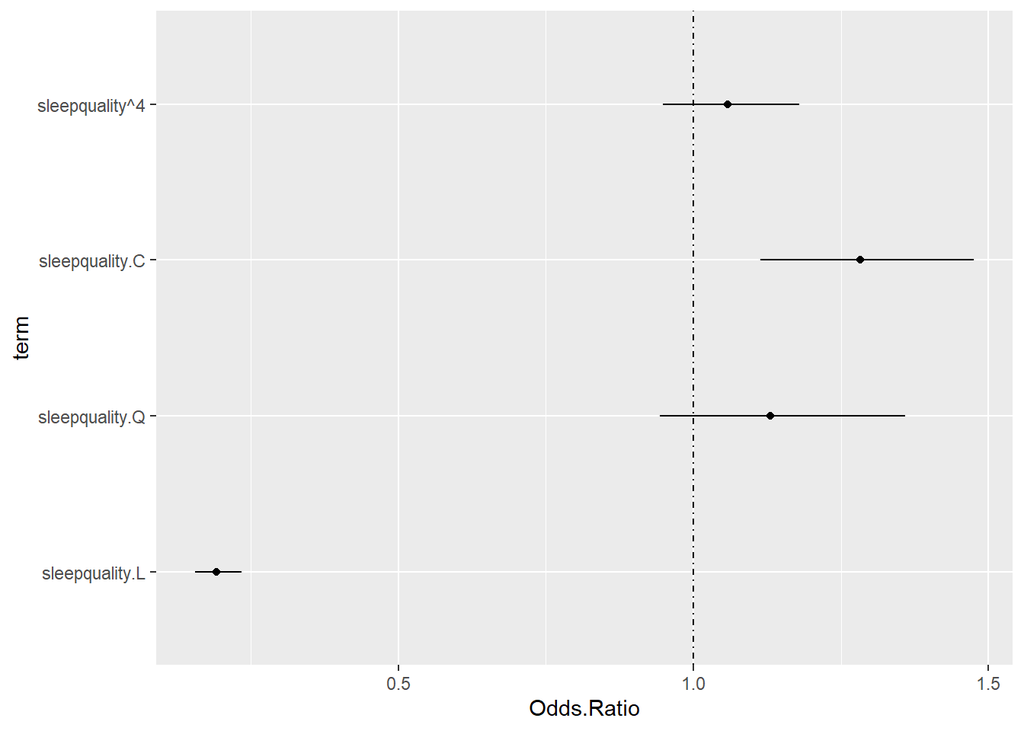

```r
## let's plot these coefficients and their CI's to increase
## readability

model0Tidy %>% ggplot (aes(Odds.Ratio, term, xmin = conf.low,
                           xmax = conf.high, height = 0)) +
                ## inserting a point for the odds ratio
                geom_point() +
                ## drawing a line at the 1 to improve readability
                geom_vline(xintercept = 1, lty = 4) +
                ## drawing an horizontal line to represent the
                ## confidence interval
                geom_errorbarh() +
                ## reordering the categorical variables in the
                ## y-axis to improve readability
                ## also removing the intercept, as it's not
                ## relevant for interpretation
                scale_y_discrete(limits = c('sleepquality.L',
                                            'sleepquality.Q',
                                            'sleepquality.C',
                                            'sleepquality^4'))
```

The p-value of the term *sleepquality.L* being significant means that there is a statistically significant **linear** association between increasing *sleepquality* values and decreasing the probability of *pain* being present (due to the less than 1 Odds Ratio).

We can also see that our model finds a significant relationship between *sleepquality.C* and *pain*. This finding is a little bit harder to interpret, but according to [this stack overflow post](https://stackoverflow.com/questions/57297771/interpretation-of-l-q-c-4-for-logistic-regression), we can interpret the third order polynomial as jerk.

A different approach would be to either consider the variable as continuous or categorical. As we don’t have to test for any assumptions in order to consider it categorical, let’s proceed with that first.

```r
## changing the variable to categorical
PPCRdata$sleepquality <- factor(PPCRdata$sleepquality, ordered = FALSE)

## running the model
model1 <- glm (data = PPCRdata, formula = pain ~ sleepquality,
               family = "binomial")
summary(model1)
```

```
##
## Call:
## glm(formula = pain ~ sleepquality, family = "binomial", data = PPCRdata)
##
## Deviance Residuals:
##     Min       1Q   Median       3Q      Max
## -1.5481  -0.8119  -0.8119   1.2745   1.6638
##
## Coefficients:
##                       Estimate Std. Error z value Pr(>|z|)
## (Intercept)             0.8391     0.1430   5.866 4.45e-09 ***
## sleepqualityBad        -0.4186     0.1586  -2.639  0.00832 **
## sleepqualityFair       -1.0645     0.1515  -7.028 2.10e-12 ***
## sleepqualityGood       -1.7796     0.1482 -12.011  < 2e-16 ***
## sleepqualityVery good  -1.9347     0.1624 -11.910  < 2e-16 ***
## ---
## Signif. codes:  0 '***' 0.001 '**' 0.01 '*' 0.05 '.' 0.1 ' ' 1
##
## (Dispersion parameter for binomial family taken to be 1)
##
##     Null deviance: 9184.1  on 6967  degrees of freedom
## Residual deviance: 8669.3  on 6963  degrees of freedom
##   (6 observations deleted due to missingness)
## AIC: 8679.3
##
## Number of Fisher Scoring iterations: 4
```

```r
## Let's proceed with the same transformations we did
## when we built the model with the variable considered
## as ordinal, in order to improve readability

model1Tidy <- tidy(model1, conf.int = TRUE, exponentiate = TRUE)
model1Tidy %>% rename(Odds.Ratio = estimate) -> model1Tidy
model1Tidy
```

```
## # A tibble: 5 × 7
##   term                  Odds.Ratio std.error statistic  p.value conf.low conf.…¹
##   <chr>                      <dbl>     <dbl>     <dbl>    <dbl>    <dbl>   <dbl>
## 1 (Intercept)                2.31      0.143      5.87 4.45e- 9    1.76    3.08
## 2 sleepqualityBad            0.658     0.159     -2.64 8.32e- 3    0.480   0.895
## 3 sleepqualityFair           0.345     0.151     -7.03 2.10e-12    0.255   0.462
## 4 sleepqualityGood           0.169     0.148    -12.0  3.10e-33    0.126   0.225
## 5 sleepqualityVery good      0.144     0.162    -11.9  1.05e-32    0.105   0.198
## # … with abbreviated variable name ¹conf.high
```

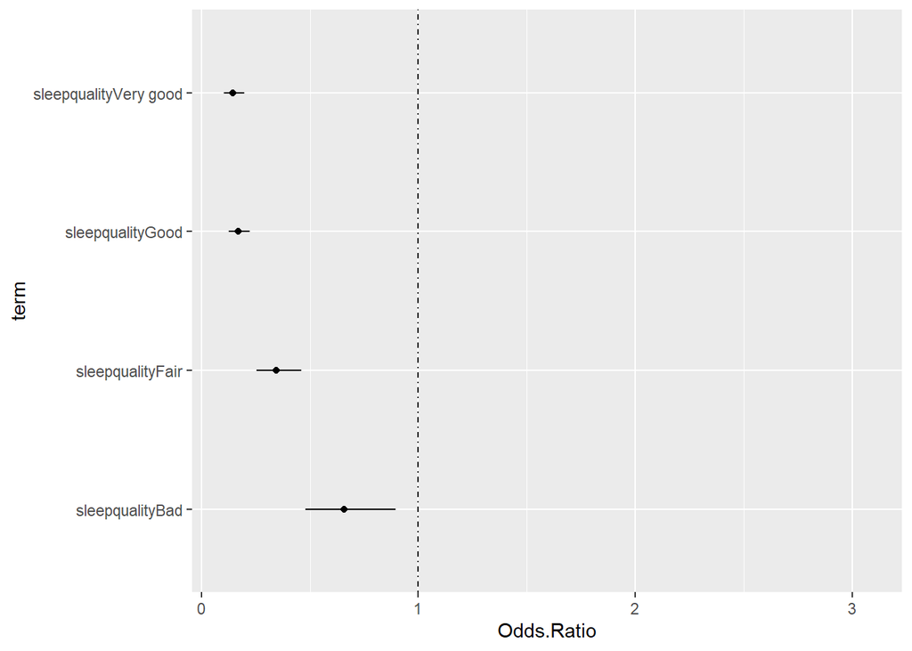

```r
## Let's also plot this one for increased readability

model1Tidy %>% ggplot (aes(Odds.Ratio, term, xmin = conf.low,
                           xmax = conf.high, height = 0)) +
                ## inserting a point for the odds ratio
                geom_point() +
                ## drawing a line at the 1 to improve readability
                geom_vline(xintercept = 1, lty = 4) +
                ## drawing an horizontal line to represent the
                ## confidence interval
                geom_errorbarh() +
                ## changing the order to increase readability
                ## and removing the intercept again
                scale_y_discrete(limits = c('sleepqualityBad',
                                            'sleepqualityFair',
                                            'sleepqualityGood',
                                            'sleepqualityVery good'))
```

```r
## reestablishing the variable as ordinal
PPCRdata$sleepquality <- factor(PPCRdata$sleepquality, ordered = TRUE)
```

This analysis allows us to determine that, when using a reference level of *sleepquality* that is **very bad**, the odds of experiencing *pain* when *sleepquality* increases are significantly lower (the odds ratio of the comparison of each level with very bad sleep quality can be seen in the table above).

In this next model, we’re going to consider sleepquality as a continuous variable.

```r
## doing the transformation and saving on another variable to not lose the
## categorical information (names for each level)
PPCRdata %>% mutate(sleepquality = as.numeric(sleepquality)) -> dataNumeric

## checking to see if it worked properly
head(dataNumeric$sleepquality)
```

```
## [1] 2 4 4 4 4 4
```

Now that the variable is transformed to numeric, let’s run the model again.

```r
glm (data = dataNumeric, formula = pain ~ sleepquality,
     family = "binomial") -> model2
model2 %>% tidy(confint = TRUE, exponentiate = TRUE) %>%
        rename(Odds.Ratio = estimate) -> model2Tidy
summary(model2)
```

```
##
## Call:
## glm(formula = pain ~ sleepquality, family = "binomial", data = dataNumeric)
##
## Deviance Residuals:
##     Min       1Q   Median       3Q      Max
## -1.5719  -0.8519  -0.8519   1.2870   1.8001
##
## Coefficients:
##              Estimate Std. Error z value Pr(>|z|)
## (Intercept)   1.46494    0.09635   15.21   <2e-16 ***
## sleepquality -0.57295    0.02693  -21.27   <2e-16 ***
## ---
## Signif. codes:  0 '***' 0.001 '**' 0.01 '*' 0.05 '.' 0.1 ' ' 1
##
## (Dispersion parameter for binomial family taken to be 1)
##
##     Null deviance: 9184.1  on 6967  degrees of freedom
## Residual deviance: 8695.6  on 6966  degrees of freedom
##   (6 observations deleted due to missingness)
## AIC: 8699.6
##
## Number of Fisher Scoring iterations: 4
```

```r
model2Tidy
```

```
## # A tibble: 2 × 5
##   term         Odds.Ratio std.error statistic   p.value
##   <chr>             <dbl>     <dbl>     <dbl>     <dbl>
## 1 (Intercept)       4.33     0.0963      15.2 3.29e- 52
## 2 sleepquality      0.564    0.0269     -21.3 2.07e-100
```

```r
lrtest(model1,model2)
```

```
## Likelihood ratio test
##
## Model 1: pain ~ sleepquality
## Model 2: pain ~ sleepquality
##   #Df  LogLik Df  Chisq Pr(>Chisq)
## 1   5 -4334.7
## 2   2 -4347.8 -3 26.258  8.423e-06 ***
## ---
## Signif. codes:  0 '***' 0.001 '**' 0.01 '*' 0.05 '.' 0.1 ' ' 1
```

#### Adjusted Analysis

```r
model3 <- glm(data = PPCRdata, formula = pain ~ sleepquality + bmi + depression +
                       sex + alcohol + fracture + cancer + diabetes + dementia +
                       arthritis + heartdisease + lungdisease,
                                                        family = "binomial")
summary(model3)
```

```
##
## Call:
## glm(formula = pain ~ sleepquality + bmi + depression + sex +
##     alcohol + fracture + cancer + diabetes + dementia + arthritis +
##     heartdisease + lungdisease, family = "binomial", data = PPCRdata)
##
## Deviance Residuals:
##     Min       1Q   Median       3Q      Max
## -2.1819  -0.8382  -0.6495   1.0667   2.1151
##
## Coefficients:
##                                Estimate Std. Error z value Pr(>|z|)
## (Intercept)                   -1.389124   0.158859  -8.744  < 2e-16 ***
## sleepquality.L                -1.398815   0.115572 -12.103  < 2e-16 ***
## sleepquality.Q                 0.071046   0.100935   0.704 0.481510
## sleepquality.C                 0.195584   0.076904   2.543 0.010984 *
## sleepquality^4                 0.058029   0.059578   0.974 0.330057
## bmi                            0.028347   0.005338   5.311 1.09e-07 ***
## depressionYes                  0.292927   0.082938   3.532 0.000413 ***
## sexMale                       -0.243391   0.060430  -4.028 5.63e-05 ***
## alcoholLess than once a month -0.264266   0.097659  -2.706 0.006810 **
## alcoholOnce a month or more    0.060003   0.083980   0.714 0.474921
## fractureYes                    0.350774   0.244215   1.436 0.150908
## cancerYes                     -0.035022   0.136490  -0.257 0.797493
## diabetesYes                    0.178018   0.071239   2.499 0.012458 *
## dementiaYes                    0.285329   0.216114   1.320 0.186743
## arthritisYes                   1.168952   0.066152  17.671  < 2e-16 ***
## heartdiseaseYes                0.460042   0.101493   4.533 5.82e-06 ***
## lungdiseaseYes                 0.805832   0.116311   6.928 4.26e-12 ***
## ---
## Signif. codes:  0 '***' 0.001 '**' 0.01 '*' 0.05 '.' 0.1 ' ' 1
##
## (Dispersion parameter for binomial family taken to be 1)
##
##     Null deviance: 8872.2  on 6752  degrees of freedom
## Residual deviance: 7802.1  on 6736  degrees of freedom
##   (221 observations deleted due to missingness)
## AIC: 7836.1
##
## Number of Fisher Scoring iterations: 4
```

The interpretation of this model regarding our main independent variable, *sleepquality*, is hard to do, as the model is considering it as ordinal. Let’s run it again with the model considering it as categorical.

```r
## changing the variable to categorical
PPCRdata$sleepquality <- factor(PPCRdata$sleepquality, ordered = FALSE)

## running the model
model4 <- glm (data = PPCRdata, formula = pain ~ sleepquality + depression +
                       sex + alcohol + fracture + cancer + diabetes + dementia +
                       arthritis + heartdisease + lungdisease,
                                                        family = "binomial")
summary(model4)
```

```
##
## Call:
## glm(formula = pain ~ sleepquality + depression + sex + alcohol +
##     fracture + cancer + diabetes + dementia + arthritis + heartdisease +
##     lungdisease, family = "binomial", data = PPCRdata)
##
## Deviance Residuals:
##     Min       1Q   Median       3Q      Max
## -2.2676  -0.8406  -0.6633   1.0708   2.0134
##
## Coefficients:
##                               Estimate Std. Error z value Pr(>|z|)
## (Intercept)                    0.27168    0.15810   1.718 0.085716 .
## sleepqualityBad               -0.34944    0.16902  -2.067 0.038697 *
## sleepqualityFair              -0.85952    0.16210  -5.302 1.14e-07 ***
## sleepqualityGood              -1.46429    0.15857  -9.234  < 2e-16 ***
## sleepqualityVery good         -1.62064    0.17367  -9.332  < 2e-16 ***
## depressionYes                  0.33385    0.08185   4.079 4.53e-05 ***
## sexMale                       -0.27075    0.05917  -4.576 4.75e-06 ***
## alcoholLess than once a month -0.26586    0.09671  -2.749 0.005980 **
## alcoholOnce a month or more    0.06114    0.08283   0.738 0.460472
## fractureYes                    0.30154    0.23762   1.269 0.204437
## cancerYes                     -0.05806    0.13508  -0.430 0.667343
## diabetesYes                    0.23136    0.06965   3.322 0.000894 ***
## dementiaYes                    0.26235    0.21579   1.216 0.224060
## arthritisYes                   1.16886    0.06526  17.910  < 2e-16 ***
## heartdiseaseYes                0.44869    0.10022   4.477 7.56e-06 ***
## lungdiseaseYes                 0.80416    0.11566   6.953 3.57e-12 ***
## ---
## Signif. codes:  0 '***' 0.001 '**' 0.01 '*' 0.05 '.' 0.1 ' ' 1
##
## (Dispersion parameter for binomial family taken to be 1)
##
##     Null deviance: 9056.5  on 6875  degrees of freedom
## Residual deviance: 8002.9  on 6860  degrees of freedom
##   (98 observations deleted due to missingness)
## AIC: 8034.9
##
## Number of Fisher Scoring iterations: 4
```

```r
## reestablishing the variable as ordinal
PPCRdata$sleepquality <- factor(PPCRdata$sleepquality, ordered = TRUE)
```

According to the [UCLA Office of Advanced Research Computing (OARC)](https://stats.oarc.ucla.edu/r/dae/logit-regression/), in order to test for an overall effect of the *sleepquality* variable, we can employ the wald.test function from the aod library.

```r
library(aod)
wald.test(b = coef(model4), Sigma = vcov(model4), Terms = 2:5)
```

```
## Wald test:
## ----------
##
## Chi-squared test:
## X2 = 294.0, df = 4, P(> X2) = 0.0
```

We can also compute the odds-ratios for each variable.

```r
exp(cbind(OR = coef(model4), confint(model4)))
```

```
##                                      OR     2.5 %    97.5 %
## (Intercept)                   1.3121711 0.9660018 1.7969168
## sleepqualityBad               0.7050831 0.5042023 0.9787760
## sleepqualityFair              0.4233649 0.3067546 0.5795842
## sleepqualityGood              0.2312419 0.1686826 0.3143406
## sleepqualityVery good         0.1977717 0.1401186 0.2769841
## depressionYes                 1.3963304 1.1891176 1.6391048
## sexMale                       0.7628072 0.6791680 0.8564945
## alcoholLess than once a month 0.7665498 0.6331041 0.9251156
## alcoholOnce a month or more   1.0630453 0.9031218 1.2496889
## fractureYes                   1.3519343 0.8483374 2.1586111
## cancerYes                     0.9435959 0.7224028 1.2272636
## diabetesYes                   1.2603159 1.0991786 1.4442999
## dementiaYes                   1.2999856 0.8528537 1.9908678
## arthritisYes                  3.2183123 2.8327610 3.6587073
## heartdiseaseYes               1.5662664 1.2867576 1.9062333
## lungdiseaseYes                2.2348225 1.7827701 2.8061735
```

#### Testing the assumptions of the model

At this point, I haven’t yet learned how to properly test for the assumptions of the logistic regression model. On a later opportunity, I’ll try to remedy this situation. For now, I’ll include some commands that were listed as useful in the [R you ready for R?](https://bookdown.org/wadetroberts/r-you-ready-for-r/multiple-logistic-regression.html#model-fit-statistics-for-multiple-logistic-regression) e-book.

```r
library(blorr)
blr_model_fit_stats(model4)
```

```
##                               Model Fit Statistics
## ---------------------------------------------------------------------------------
## Log-Lik Intercept Only:     -4596.949    Log-Lik Full Model:            -4001.434
## Deviance(6860):              8002.867    LR(15):                         1191.031
##                                          Prob > LR:                         0.000
## MCFadden's R2                   0.130    McFadden's Adj R2:                 0.126
## ML (Cox-Snell) R2:              0.157    Cragg-Uhler(Nagelkerke) R2:        0.214
## McKelvey & Zavoina's R2:        0.187    Efron's R2:                        0.150
## Count R2:                       0.696    Adj Count R2:                      0.176
## BIC:                         8144.240    AIC:                            8034.867
## ---------------------------------------------------------------------------------
```

```r
blr_test_hosmer_lemeshow(model4)
```

```
##            Partition for the Hosmer & Lemeshow Test
## --------------------------------------------------------------
##                         def = 1                 def = 0
## Group    Total    Observed    Expected    Observed    Expected
## --------------------------------------------------------------
##   1       961       158        168.21       803        792.79
##   2       600       103        119.71       497        480.29
##   3       979       230        226.21       749        752.79
##   4       249        55        60.49        194        188.51
##   5       679       195        192.23       484        486.77
##   6       706       247        240.76       459        465.24
##   7       687       329        283.09       358        403.91
##   8       676       329        332.86       347        343.14
##   9       653       377        388.82       276        264.18
##  10       686       516        526.63       170        159.37
## --------------------------------------------------------------
##
##      Goodness of Fit Test
## ------------------------------
## Chi-Square    DF    Pr > ChiSq
## ------------------------------
##  19.2685      8       0.0135
## ------------------------------
```

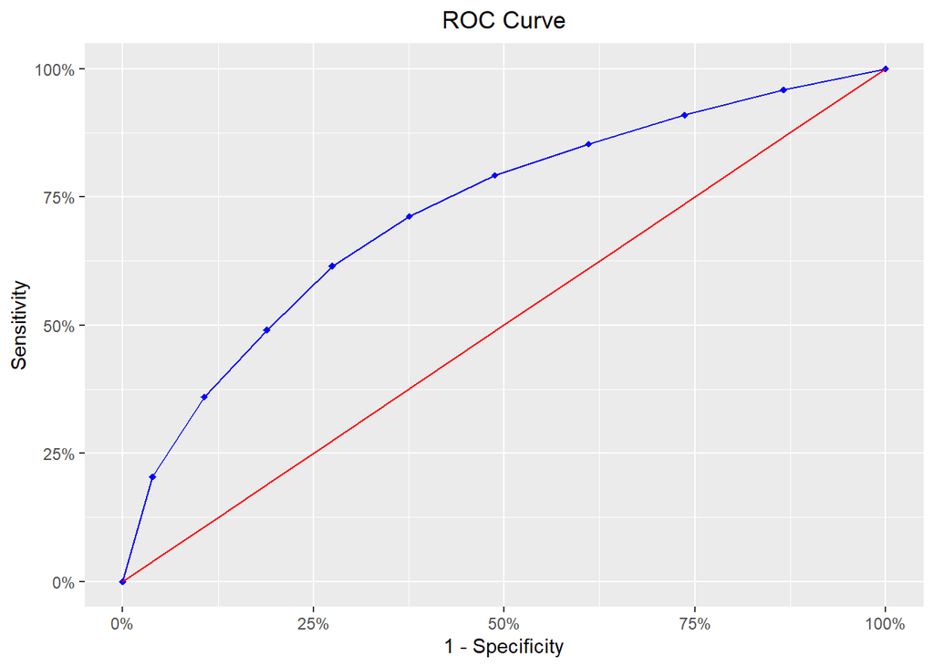

```r
blr_roc_curve(blr_gains_table(model4))
```

```r
car::vif(model4)
```

```
##                  GVIF Df GVIF^(1/(2*Df))
## sleepquality 1.042720  4        1.005243
## depression   1.054232  1        1.026758
## sex          1.109953  1        1.053543
## alcohol      1.082371  2        1.019986
## fracture     1.006077  1        1.003034
## cancer       1.006678  1        1.003333
## diabetes     1.018426  1        1.009171
## dementia     1.013305  1        1.006631
## arthritis    1.018783  1        1.009348
## heartdisease 1.022240  1        1.011059
## lungdisease  1.003984  1        1.001990
```

### Association between *sleepquality* and *pain*

In order to do this analysis I’ll try to follow the instructions from the [UCLA OARC - Ordinal Logistic Regression | R Data Analysis Example](https://stats.oarc.ucla.edu/r/dae/ordinal-logistic-regression/).

As the original article by [Montelhão et al](https://pubmed.ncbi.nlm.nih.gov/34968438/) tested for bidirectional associations, let’s try to replicate that as well. In this case, the dependent variable is ordinal, therefore we will run an ordinal logistical regression.

```r
## loading the library required to run the model
library(MASS)

## running the model
model5 <- polr (data = PPCRdata, formula = sleepquality ~ pain + depression +
                       sex + alcohol + fracture + cancer + diabetes + dementia +
                       arthritis + heartdisease + lungdisease, Hess = TRUE)
summary(model5)
```

```
## Call:
## polr(formula = sleepquality ~ pain + depression + sex + alcohol +
##     fracture + cancer + diabetes + dementia + arthritis + heartdisease +
##     lungdisease, data = PPCRdata, Hess = TRUE)
##
## Coefficients:
##                                  Value Std. Error  t value
## painYes                       -0.84185    0.05035 -16.7198
## depressionYes                 -0.80210    0.06832 -11.7395
## sexMale                        0.15952    0.04911   3.2482
## alcoholLess than once a month  0.04327    0.07702   0.5617
## alcoholOnce a month or more    0.01517    0.06906   0.2197
## fractureYes                   -0.32948    0.20157  -1.6346
## cancerYes                     -0.02144    0.11507  -0.1863
## diabetesYes                   -0.10778    0.05948  -1.8119
## dementiaYes                   -0.91867    0.17310  -5.3070
## arthritisYes                  -0.28556    0.05808  -4.9162
## heartdiseaseYes               -0.30757    0.08458  -3.6365
## lungdiseaseYes                -0.13941    0.09892  -1.4093
##
## Intercepts:
##                Value    Std. Error t value
## Very bad|Bad    -4.0756   0.0801   -50.8593
## Bad|Fair        -2.2508   0.0509   -44.2265
## Fair|Good       -0.9173   0.0429   -21.3659
## Good|Very good   1.5700   0.0477    32.9175
##
## Residual Deviance: 17558.49
## AIC: 17590.49
## (98 observations deleted due to missingness)
```

In R, this doesn’t produce the p-values, so let’s add those, as our sample size is large enough that they are reasonable approximations.

```r
## getting the coefficients
ctable <- coef(summary(model5))

## getting the respective p-values from the normal distribution
p <- pnorm(abs(ctable[, "t value"]), lower.tail = FALSE) * 2

## creating a table with the respective p-values added
ctable <- cbind(ctable, "p value" = p)
ctable
```

```
##                                     Value Std. Error     t value       p value
## painYes                       -0.84185213 0.05035057 -16.7198121  9.401510e-63
## depressionYes                 -0.80209637 0.06832463 -11.7394915  7.996578e-32
## sexMale                        0.15951906 0.04911027   3.2481813  1.161452e-03
## alcoholLess than once a month  0.04326586 0.07702191   0.5617345  5.742970e-01
## alcoholOnce a month or more    0.01517377 0.06906242   0.2197110  8.260963e-01
## fractureYes                   -0.32947959 0.20156566  -1.6346018  1.021325e-01
## cancerYes                     -0.02143899 0.11507479  -0.1863049  8.522057e-01
## diabetesYes                   -0.10777592 0.05948076  -1.8119459  6.999456e-02
## dementiaYes                   -0.91866611 0.17310421  -5.3070119  1.114369e-07
## arthritisYes                  -0.28555635 0.05808419  -4.9162492  8.821807e-07
## heartdiseaseYes               -0.30756875 0.08457810  -3.6365059  2.763613e-04
## lungdiseaseYes                -0.13940950 0.09891811  -1.4093425  1.587339e-01
## Very bad|Bad                  -4.07563821 0.08013557 -50.8592932  0.000000e+00
## Bad|Fair                      -2.25076521 0.05089175 -44.2265206  0.000000e+00
## Fair|Good                     -0.91731844 0.04293376 -21.3659005 2.774513e-101
## Good|Very good                 1.56998540 0.04769459  32.9174731 1.236066e-237
```

```r
## creating confidence intervals
ci<-confint.default(model5)

## exponentiating the log-odds and the confidence intervals
## in order to create the odds-ratios and the respective CI's
exp(cbind(OR = coef(model5), ci))
```

```
##                                      OR     2.5 %    97.5 %
## painYes                       0.4309117 0.3904180 0.4756054
## depressionYes                 0.4483880 0.3921895 0.5126394
## sexMale                       1.1729466 1.0653088 1.2914601
## alcoholLess than once a month 1.0442155 0.8979020 1.2143707
## alcoholOnce a month or more   1.0152895 0.8867554 1.1624544
## fractureYes                   0.7192980 0.4845469 1.0677801
## cancerYes                     0.9787892 0.7811552 1.2264250
## diabetesYes                   0.8978288 0.7990306 1.0088431
## dementiaYes                   0.3990510 0.2842378 0.5602411
## arthritisYes                  0.7515960 0.6707228 0.8422205
## heartdiseaseYes               0.7352323 0.6229190 0.8677959
## lungdiseaseYes                0.8698717 0.7165656 1.0559770
```

#### Testing for the Proportional Odds Assumption

This is something to consider further on. At this point, I haven’t yet figured out exactly how to do it, but I’ll try to follow the instructions from the [Office of Advanced Research Computing](https://stats.oarc.ucla.edu/r/dae/ordinal-logistic-regression/) on another day.